# Crear plantilla de proyecto personalizadas

## Estructura inicial de la plantilla

Para eso necesitamos ir a la terminal y vamos a posicionarnos en cookiecutter mediante los siguientes comandos.

```
cd cookiecutter-personal
```

Una vez ahí, necesitamos borrar la carpeta **cookiecutter_testing** que habíamos creado en la anterior clase con el comando del repositorio de git hub.

[figure not shown]

### Creando la estructura

Para ello abrimos VS Code con el comando `code .`, se nos abrirá. Por lo que haremos lo siguiente:

1.- La vamos a nombrar como (contendrá todo el contenido que queramos para el proyecto):

```
#Esto es una sintaxis de JINJA
#Ademas es un bloque de expresión
#Vamos a sustituir el valor de una variable
#Y sustituirlo
{{cookiecutter.project_slug}}
```

[figure not shown]

Dentro de la carpeta podemos definir archivos, es decir crear un archivo README.md. También podemos crear carpetas.

[figure not shown]

Podemos editar el **README.md** y usar la sintaxis de NINJA para personalizar nuestro proyecto.

**Contenido de README.md**

```
#Este es el titulo n1 del proyecto con la sintaxis JINJA
# {{ cookiecutter.project_title}}

#Aquí tenemos nombre de autor
By {{cookiecutter.author_name}}

#Este otro es un titulo n3 que tiene la descripción del proyecto
### {{cookiecutter.project_description}}
```

No solo podemos crear un **README.md** con la sintaxis de NINJA, sino que podemos crear los archivos que tengan cierta sintaxis. Por ejemplo, podemos crear un archivo environment.yml

En el contenido escribimos lo siguiente (hay que fijarnos en la sintaxis de JINJA):

# Para poder crear un entorno en conda corremos

# conda env create --file environment.yml

```
#NOMBRE DEL PROYECTO
name: {{cookiecutter.project_slug}}
channels:
- anaconda
- conda-forge
- default
dependencies:
#BLOQUE DECLARATIVO
{% if cookiecutter.project_packages == 'All' -%}
- fs
- jupyter
- jupyterlab
- pathlib

{% endif -%}
- pip

{% if cookiecutter.project_packages == "All" -%}
- pyprojroot

{% endif -%}
- python={{ cookiecutter.python_version }}
- pip:
    {% if cookiecutter.project_packages == "All" -%}
    - pyhere
    {% endif -%}
```

Recordemos que debemos tener el orden de esta forma:

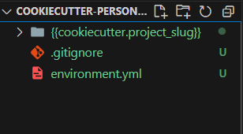

[figure not shown]

## Archivo de configuración

Para poder desplegar el entorno y la plantilla creada necesitamos un archivo de configuración cookiecutter.json.

Dentro de este archivo crearemos todas las variables que utilizamos anteriormente en nuestro proyecto.

NO COPIES LAS LINEAS EN ROJO (#) son comentarios para guiarnos

```
{
    #(OJO si no colocas nada, existe un valor por defecto que es el que esta entre comillas)
    #titulo del proyecto
    "project_title": "Project Title",
    #nombre del proyecto
    "project_slug": "project_personal",
    #Descripción del proyecto
    "project_description": "This is a project",
    #Nombre del autor
    "author_name":"Type your name",
    #Paquetes necesarios para el proyecto
    "project_packages":["All","Minimal"],
    #Versión de Python
    "python_version":"3.7"
}
```

Así que ya tenemos la estructura donde tenemos los siguientes archivos y carpetas:

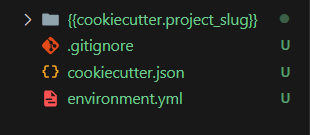

En ella vemos que tenemos el **archivo de configuración** , que nos da los valores de las variables que establecimos por defecto

### Ejecutando archivo JSON

Nos posicionamos en el archivo cookiecutter.json y presionamos `Ctrl+Shift+P` para abrir una terminal escribimos **terminal** y escogemos (create new terminal), así nos abre una terminal con el ambiente base, pero tenemos que cambiarlo al que contiene **cookicutter**.

Procederé a correr los siguientes comandos:

```
#Aquí tengo mi entorno con cookie
conda activate env
#Limpiar pantalla
clear
#Voy a indicarle que use cookiecutter desde esta carpeta
cookiecutter .
```

Después me va a pedir ingresar lo siguiente:

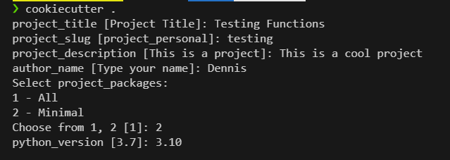

Una vez que se haya finalizado vemos que me ha creado una nueva carpeta con una estructura dentro.

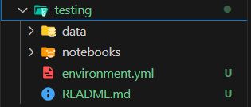

Así logramos crear un proyecto con la plantilla dada y para no confundirnos vamos a borrar la carpeta que hemos creado para solo tener los archivos de configuración.